# Estadística Descriptiva Multivariada

# Ejemplo 2: Calidad de vida — ECV DANE

## Encuesta Nacional de Calidad de Vida

La **ECV** es el principal instrumento del DANE para medir las condiciones de vida de los hogares colombianos. Se realiza anualmente con cobertura nacional y departamental.

El conjunto de datos que usaremos contiene **15 indicadores de calidad de vida** para los **33 departamentos** de Colombia (incluido Bogotá D.C.), construidos a partir de los resultados publicados por el DANE para la ECV 2022.

Todas las variables están en escala 0–100 con la convención:

> **Mayor valor = mejor condición de vida**

Los indicadores en escala inversa (analfabetismo, hacinamiento, IPM) se transformaron como $I_j = 100 - \text{indicador}$.

## Carga de los datos

```r
library(pacman)
p_load(tidyverse, janitor, corrplot)

url <- "https://github.com/jgbabativam/Curso_Multivariado/raw/main/Datos/"
ecv <- read.csv(paste0(url, "ecv_departamentos_2022.csv"), header = TRUE) |>
       column_to_rownames("departamento")
```

| departamento | piso_adec | paredes_adec | acueducto | alcantarillado | energia | gas_natural | internet | nevera | computador | afiliacion_salud | educ_superior | asistencia_esc | lit_adultos | sin_hacinamiento | sin_ipm |
| --- | --- | --- | --- | --- | --- | --- | --- | --- | --- | --- | --- | --- | --- | --- | --- |
| Bogotá D.C. | 98.2 | 99.1 | 97.8 | 96.9 | 99.8 | 78.3 | 77.8 | 96.8 | 61.8 | 95.8 | 34.8 | 93.8 | 98.5 | 95.8 | 95.9 |
| Atlántico | 90.4 | 93.8 | 92.6 | 87.9 | 99.2 | 61.9 | 59.7 | 90.9 | 42.9 | 92.9 | 21.9 | 88.9 | 96.5 | 92.9 | 91.1 |
| Valle del Cauca | 88.3 | 92.7 | 90.1 | 84.1 | 99.1 | 54.8 | 58.1 | 89.7 | 41.8 | 91.2 | 20.8 | 87.8 | 96.0 | 92.2 | 89.2 |
| Antioquia | 87.1 | 91.3 | 87.9 | 82.4 | 99.3 | 52.1 | 56.9 | 89.2 | 40.7 | 92.1 | 19.7 | 87.1 | 96.2 | 92.1 | 90.3 |
| Quindío | 90.5 | 92.1 | 91.7 | 87.2 | 99.7 | 44.7 | 62.3 | 91.3 | 45.9 | 93.8 | 22.8 | 89.7 | 97.2 | 94.2 | 92.8 |
| Risaralda | 89.1 | 91.5 | 89.8 | 84.3 | 99.8 | 41.9 | 59.8 | 89.8 | 43.8 | 92.7 | 21.7 | 88.8 | 97.0 | 93.1 | 91.9 |
| Caldas | 85.3 | 88.2 | 85.9 | 79.8 | 99.1 | 37.8 | 54.7 | 86.9 | 39.7 | 91.1 | 18.9 | 86.9 | 96.5 | 92.9 | 90.2 |
| San Andrés | 82.1 | 85.4 | 87.6 | 83.2 | 99.2 | 9.8 | 49.8 | 85.7 | 37.9 | 89.2 | 17.8 | 84.8 | 95.9 | 90.8 | 87.9 |
| Santander | 86.2 | 89.7 | 84.3 | 79.7 | 99.2 | 48.2 | 51.7 | 87.8 | 37.8 | 92.8 | 19.8 | 86.7 | 97.2 | 93.2 | 91.3 |
| Meta | 78.4 | 83.1 | 77.8 | 72.8 | 98.3 | 22.3 | 39.8 | 81.9 | 29.8 | 89.7 | 14.9 | 83.8 | 95.5 | 90.9 | 87.1 |
| Casanare | 79.1 | 84.2 | 77.2 | 72.3 | 98.7 | 18.1 | 38.2 | 82.7 | 27.9 | 90.8 | 12.8 | 82.9 | 95.8 | 90.2 | 86.3 |
| Cundinamarca | 83.5 | 87.3 | 82.1 | 77.4 | 98.9 | 30.2 | 44.9 | 85.8 | 33.7 | 91.7 | 16.9 | 85.7 | 96.5 | 92.1 | 89.2 |
| Boyacá | 80.2 | 83.8 | 78.9 | 73.1 | 97.8 | 25.3 | 37.9 | 81.7 | 27.8 | 90.1 | 14.8 | 83.7 | 96.0 | 91.1 | 87.3 |
| Tolima | 77.8 | 82.1 | 76.8 | 70.8 | 97.9 | 28.1 | 36.8 | 79.8 | 26.9 | 88.9 | 13.9 | 82.8 | 94.5 | 90.2 | 85.1 |
| Nte. de Santander | 81.3 | 84.7 | 80.7 | 74.6 | 98.1 | 34.7 | 39.7 | 82.7 | 29.7 | 89.7 | 15.8 | 83.9 | 95.5 | 91.2 | 87.2 |
| Huila | 77.1 | 80.3 | 75.8 | 69.9 | 97.8 | 27.2 | 35.9 | 78.9 | 25.8 | 88.8 | 13.7 | 81.8 | 94.2 | 89.1 | 84.3 |
| Arauca | 68.4 | 72.5 | 65.3 | 57.9 | 96.9 | 11.9 | 24.7 | 72.1 | 17.9 | 86.9 | 9.9 | 78.8 | 92.5 | 86.2 | 78.2 |
| Caquetá | 65.1 | 69.3 | 62.8 | 55.7 | 96.2 | 8.2 | 22.8 | 69.2 | 15.8 | 85.8 | 8.8 | 77.9 | 92.0 | 85.1 | 77.1 |
| Putumayo | 63.2 | 67.1 | 60.2 | 53.4 | 95.3 | 6.1 | 19.9 | 65.9 | 13.9 | 84.9 | 7.8 | 76.8 | 91.5 | 83.2 | 74.2 |
| Cesar | 67.5 | 71.4 | 64.7 | 57.8 | 96.8 | 14.8 | 24.8 | 70.3 | 17.8 | 86.8 | 9.9 | 78.7 | 91.8 | 84.9 | 77.3 |
| Magdalena | 64.3 | 68.9 | 61.9 | 55.1 | 96.1 | 11.9 | 21.8 | 66.8 | 14.9 | 85.7 | 8.7 | 77.8 | 91.0 | 83.8 | 75.2 |
| Bolívar | 68.2 | 72.8 | 65.8 | 59.7 | 97.2 | 19.7 | 27.1 | 71.8 | 19.7 | 86.9 | 11.8 | 78.7 | 92.2 | 86.1 | 79.1 |
| Sucre | 62.1 | 65.7 | 59.7 | 52.8 | 95.3 | 9.8 | 20.9 | 64.9 | 13.8 | 84.8 | 7.9 | 76.9 | 90.5 | 82.9 | 74.3 |
| Córdoba | 60.5 | 64.2 | 57.9 | 51.2 | 95.1 | 8.1 | 18.8 | 62.8 | 12.9 | 83.9 | 7.8 | 75.1 | 89.8 | 81.8 | 72.1 |
| Nariño | 61.2 | 65.1 | 58.7 | 51.8 | 93.8 | 8.7 | 19.7 | 63.7 | 12.8 | 84.8 | 7.7 | 75.8 | 90.2 | 83.1 | 73.2 |
| Cauca | 59.4 | 63.4 | 55.9 | 49.3 | 92.9 | 7.2 | 17.2 | 60.9 | 11.2 | 82.9 | 6.9 | 73.9 | 89.5 | 81.2 | 70.3 |
| La Guajira | 54.1 | 62.8 | 51.8 | 48.7 | 91.2 | 3.9 | 17.8 | 63.8 | 10.8 | 79.8 | 6.8 | 73.8 | 86.0 | 73.1 | 60.2 |
| Chocó | 47.2 | 56.9 | 46.7 | 18.9 | 88.7 | 0.2 | 14.9 | 58.7 | 9.8 | 81.9 | 6.7 | 75.7 | 87.8 | 74.8 | 58.3 |
| Amazonas | 43.5 | 49.8 | 39.8 | 33.2 | 84.9 | 0.1 | 10.8 | 53.8 | 7.9 | 78.9 | 5.8 | 72.1 | 85.0 | 72.2 | 54.1 |
| Vaupés | 38.1 | 43.7 | 32.7 | 26.1 | 78.3 | 0.1 | 7.9 | 46.1 | 5.8 | 74.8 | 4.9 | 68.7 | 81.0 | 68.1 | 48.2 |
| Guainía | 36.2 | 42.1 | 31.2 | 23.8 | 75.8 | 0.1 | 6.8 | 43.8 | 4.9 | 73.2 | 3.9 | 66.9 | 80.0 | 66.2 | 45.3 |
| Guaviare | 55.3 | 59.7 | 71.7 | 67.9 | 95.1 | 4.9 | 21.7 | 77.9 | 14.8 | 87.9 | 10.8 | 81.8 | 91.0 | 83.3 | 76.2 |
| Vichada | 33.4 | 39.8 | 27.9 | 21.7 | 72.9 | 0.1 | 5.9 | 39.8 | 3.9 | 70.8 | 3.7 | 64.8 | 79.0 | 65.1 | 42.1 |

## Exploración de la matriz de correlaciones

```r
R_ecv <- cor(ecv)
corrplot(R_ecv, method  = "color", type    = "upper", order   = "hclust",
         col = colorRampPalette(c("#2b8cbe", "white", "#d7301f"))(200),  diag = FALSE,
         tl.cex  = 0.65, tl.col  = "black", addCoef.col = "black", number.cex  = 0.45, mar = c(0, 0, 1.5, 0))
```

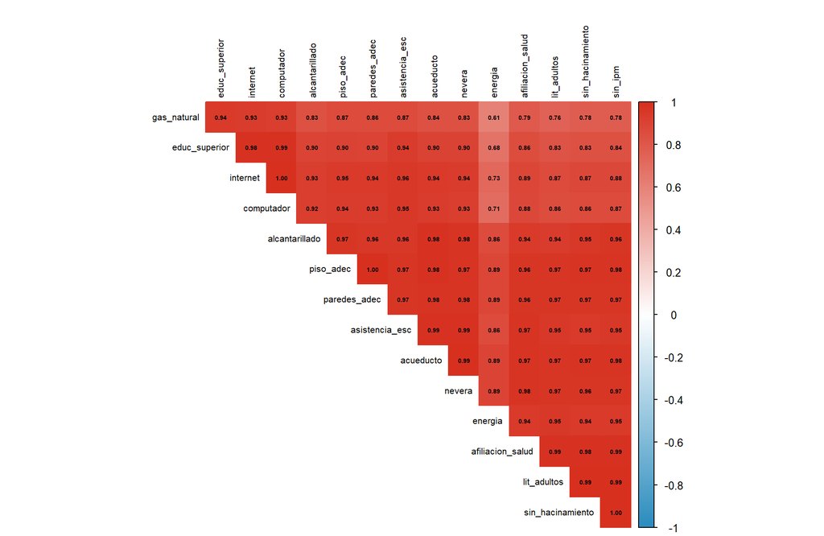

## Análisis de componentes principales

```r
pca_ecv <- PCA(ecv, graph = FALSE,
               scale.unit = TRUE,   # estandariza automáticamente
               ncp        = 5)      # retener 5 componentes
```

```r
# Tabla de valores propios
eig_ecv <- get_eigenvalue(pca_ecv)
round(eig_ecv, 3)
```

```
       eigenvalue variance.percent cumulative.variance.percent
Dim.1      13.889           92.595                      92.595
Dim.2       0.806            5.371                      97.967
Dim.3       0.103            0.688                      98.655
Dim.4       0.069            0.458                      99.113
Dim.5       0.055            0.364                      99.477
Dim.6       0.032            0.213                      99.691
Dim.7       0.027            0.183                      99.874
Dim.8       0.008            0.052                      99.925
Dim.9       0.005            0.034                      99.959
Dim.10      0.002            0.013                      99.972
Dim.11      0.002            0.011                      99.983
Dim.12      0.002            0.010                      99.993
Dim.13      0.001            0.003                      99.997
Dim.14      0.000            0.002                      99.998
Dim.15      0.000            0.002                     100.000
```

## Varianza explicada — Gráfico de sedimentación

```r
fviz_eig(pca_ecv, addlabels  = TRUE, ncp = 10) +
  labs(title = "Gráfico de sedimentación — Calidad de vida ECV 2022",
       x = "Componente", y = "% varianza explicada") + theme_bw()
```

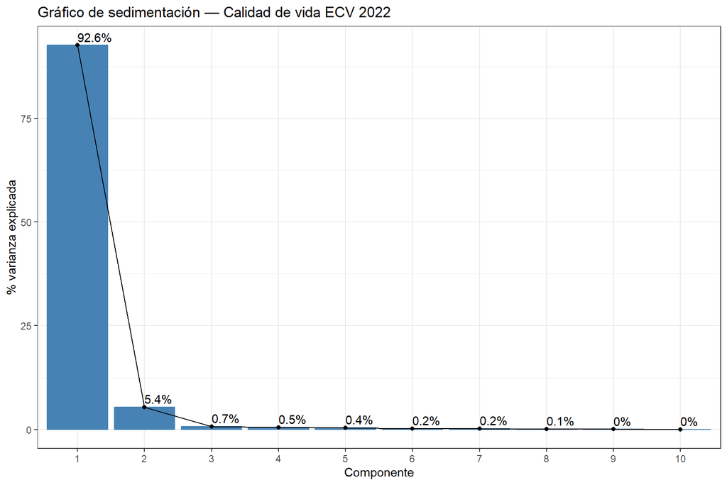

## Plano de variables — tres criterios de interpretación

- Correlaciones
- Contribuciones
- Cosenos cuadrados

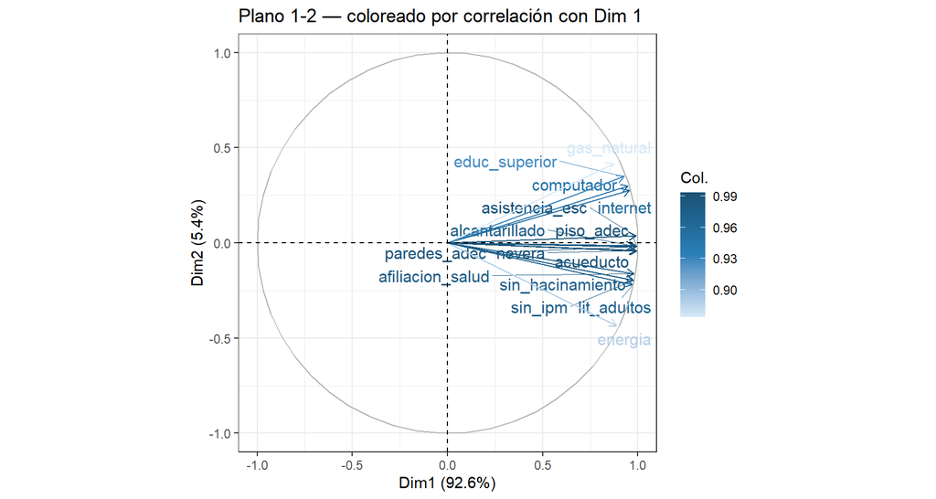

```r
fviz_pca_var(pca_ecv,
             col.var = pca_ecv$var$coord[, 1],
             gradient.cols = c("#D6EAF8", "#2980B9", "#1A5276"),
             repel = TRUE,
             title = "Plano 1-2 — coloreado por correlación con Dim 1") +
  theme_bw()
```

**Note**

Dim 1 explica ~92 % de la varianza: es un **factor tamaño**. Todas las variables correlacionan positivamente con él. Este factor refleja **infraestructura y bienestar general** (acueducto, alcantarillado, electricidad, vivienda, conectividad). `lit_adultos` y `educ_superior` podrían requerir una lectura aparte. Que una sola dimensión capture casi toda la varianza es un patrón muy común en tablas de indicadores socioeconómicos.

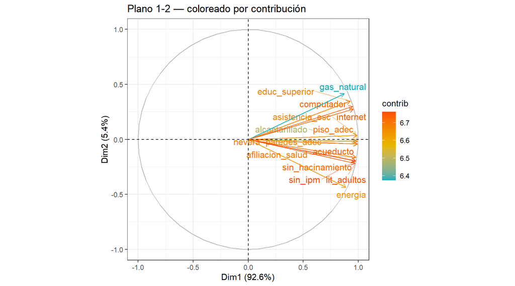

```r
fviz_pca_var(pca_ecv, col.var = "contrib",
             gradient.cols = c("#00AFBB", "#E7B800", "#FC4E07"),
             repel = TRUE,
             title = "Plano 1-2 — coloreado por contribución") +
  theme_bw()
```

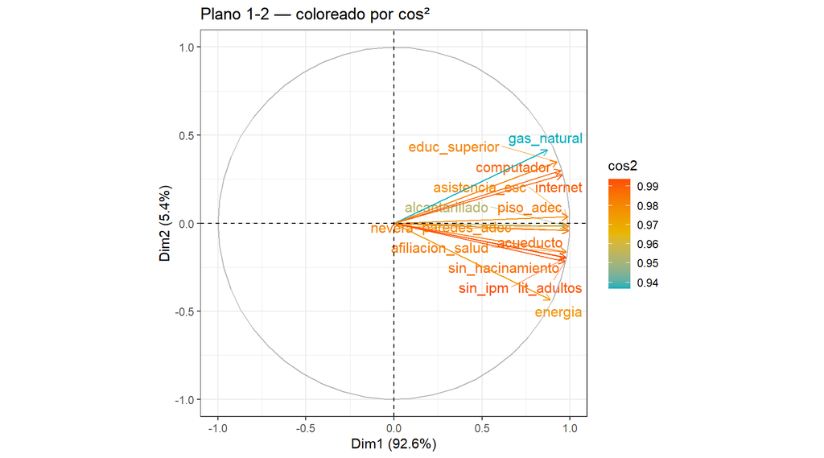

```r
fviz_pca_var(pca_ecv, col.var = "cos2",
             gradient.cols = c("#00AFBB", "#E7B800", "#FC4E07"),
             repel = TRUE,
             title = "Plano 1-2 — coloreado por cos²") +
  theme_bw()
```

## Contribuciones de los indicadores

- Dimensión 1
- Dimensión 2
- Dimensión 3

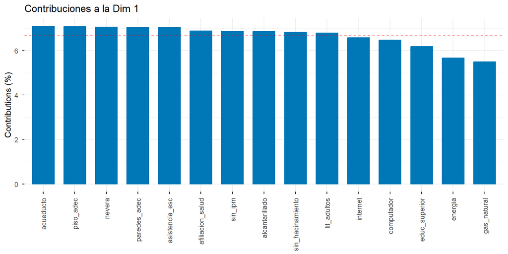

```r
fviz_contrib(pca_ecv, choice = "var", axes = 1,
             fill = "#0077b6", color = "#0077b6",
             title = "Contribuciones a la Dim 1") +
  theme(axis.text.x = element_text(angle = 90, vjust = 0.5, hjust = 1))
```

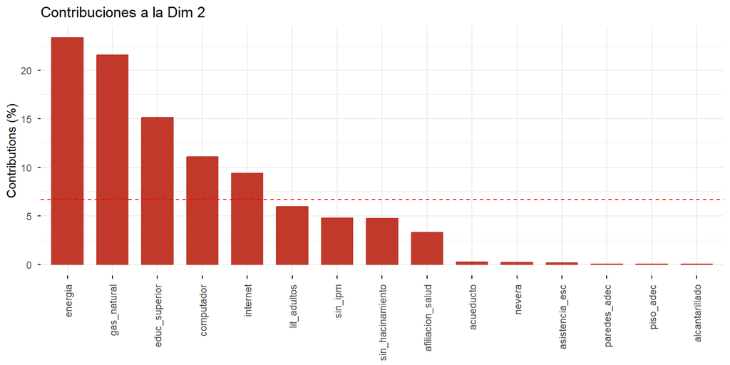

```r
fviz_contrib(pca_ecv, choice = "var", axes = 2,
             fill = "#C0392B", color = "#C0392B",
             title = "Contribuciones a la Dim 2") +
  theme(axis.text.x = element_text(angle = 90, vjust = 0.5, hjust = 1))
```

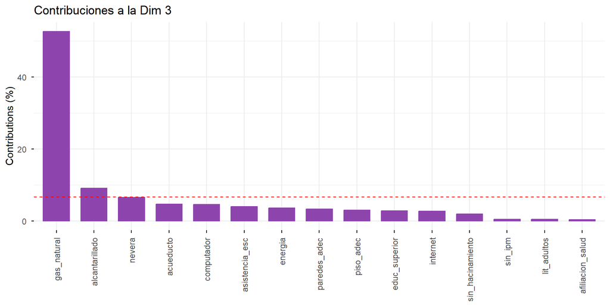

```r
fviz_contrib(pca_ecv, choice = "var", axes = 3,
             fill = "#8E44AD", color = "#8E44AD",
             title = "Contribuciones a la Dim 3") +
  theme(axis.text.x = element_text(angle = 90, vjust = 0.5, hjust = 1))
```

## Plano de individuos (departamentos)

```r
fviz_pca_ind(pca_ecv, col.ind   = "cos2", repel = TRUE, labelsize = 3.5,
             gradient.cols = c("#00AFBB", "#E7B800", "#FC4E07"),
             title     = "Plano 1-2 — Departamentos de Colombia") + theme_bw()
```

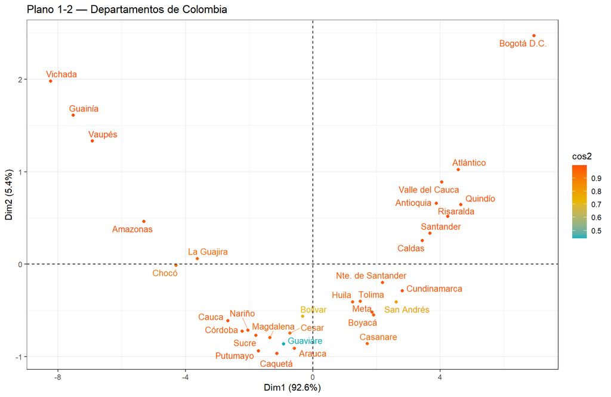

## Biplot: departamentos e indicadores

```r
fviz_pca_biplot(pca_ecv, repel = TRUE, labelsize = 3.5,
                col.var   = "#C0392B", col.ind   = "#0077b6",
                title     = "Biplot — Calidad de vida ECV 2022") + theme_bw()
```

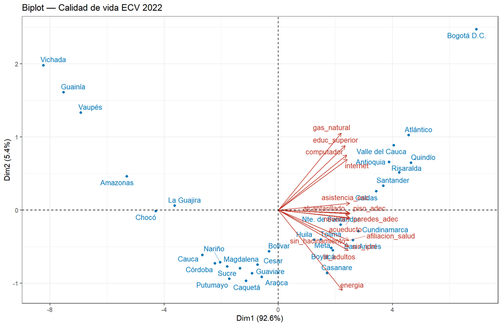

## Interpretación de las componentes — plano 1-2

[figure not shown]

## Dimensión 3: más allá del factor tamaño

- Variables (plano 1-3)
- Departamentos (plano 1-3)

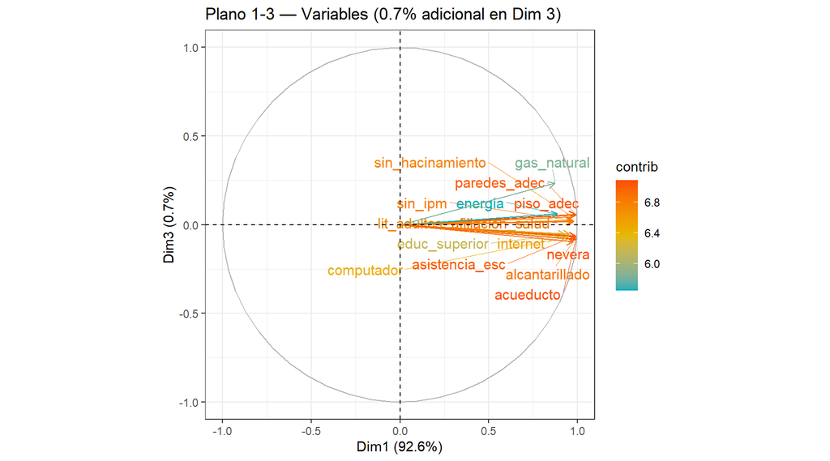

```r
fviz_pca_var(pca_ecv, axes = c(1, 3),
             col.var = "contrib",
             gradient.cols = c("#00AFBB", "#E7B800", "#FC4E07"),
             repel = TRUE,
             title = paste0("Plano 1-3 — Variables (",
                            round(eig_ecv[3, 2], 1), "% adicional en Dim 3)")) +
  theme_bw()
```

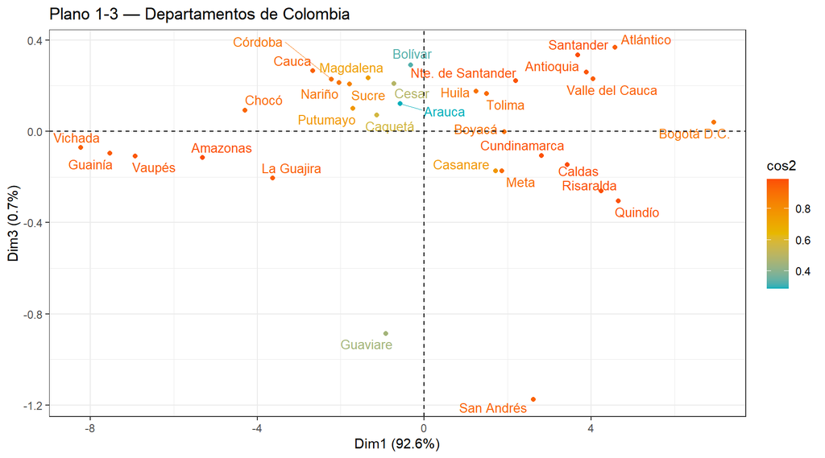

```r
fviz_pca_ind(pca_ecv, axes = c(1, 3),
             col.ind = "cos2", repel = TRUE, labelsize = 3.5,
             gradient.cols = c("#00AFBB", "#E7B800", "#FC4E07"),
             title = "Plano 1-3 — Departamentos de Colombia") +
  theme_bw()
```

La Dim 3 captura una **dimensión residual** no cubierta por el combo completo de infraestructura (Dim 1) ni por el contraste conectividad-servicios básicos (Dim 2). Las variables con alta contribución a Dim 3 señalan aspectos de calidad de vida que operan de forma **relativamente independiente** del nivel general.

## Lectura del plano: regiones de Colombia

# Variables y objetos suplementarios

## Ejemplo ARWU: variables activas vs. ilustrativas

Los rankings construidos con ponderaciones predefinidas (ARWU World Rank, Regional Rank, National Rank) pueden usarse como **variables ilustrativas** para validar si las componentes capturan los mismos patrones.

```r
arwu <- read.csv2(paste0(url, "ARWU_100_top.csv")) |> clean_names()
rownames(arwu) <- make.unique(as.character(arwu$institution))

# Invertir rankings: mayor = mejor posición
arwu <- arwu |>
  mutate(across(c(world_rank, national_rank, regional_rank), ~ -.))

# Variables activas: seis criterios académicos
vars_act <- c("alumni", "award", "hi_ci", "n_s", "pub", "pcp")
# Variables ilustrativas: tres rankings y puntaje total
vars_sup <- c("world_rank", "national_rank", "regional_rank", "total_score")

arwu_pca_data <- arwu |> select(all_of(c(vars_sup, vars_act)))

pca_arwu <- PCA(arwu_pca_data,
                quanti.sup = 1:length(vars_sup),
                graph      = FALSE)
```

## Plano de variables: criterios activos vs. ilustrativos

```r
plot.PCA(pca_arwu, choix = "var",
         title = "ARWU — Variables activas (negro) y suplementarias (azul)")
```

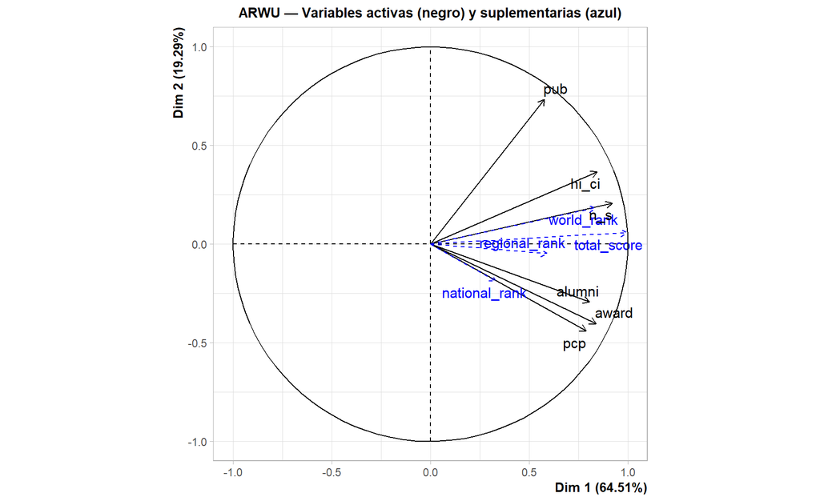

## Objetos suplementarios: universidades del rango 51-100

Las 50 universidades de menor rango se proyectan como **objetos ilustrativos** sobre el plano construido solo con el Top-50 del ARWU:

```r
# Top 50 como activos; universidades 51-100 como ilustrativas
arwu_pca_supl <- PCA(arwu_pca_data,
                     quanti.sup = 1:length(vars_sup),
                     ind.sup    = 51:100,
                     graph      = FALSE)

fviz_pca_biplot(arwu_pca_supl,
                repel        = TRUE,
                col.var      = "#C0392B",
                col.ind      = "#0077b6",
                col.ind.sup  = "#8E44AD",
                label        = "var",
                title = "ARWU — Top 50 (azul) y objetos ilustrativos 51-100 (morado)") +
  theme_bw()
```

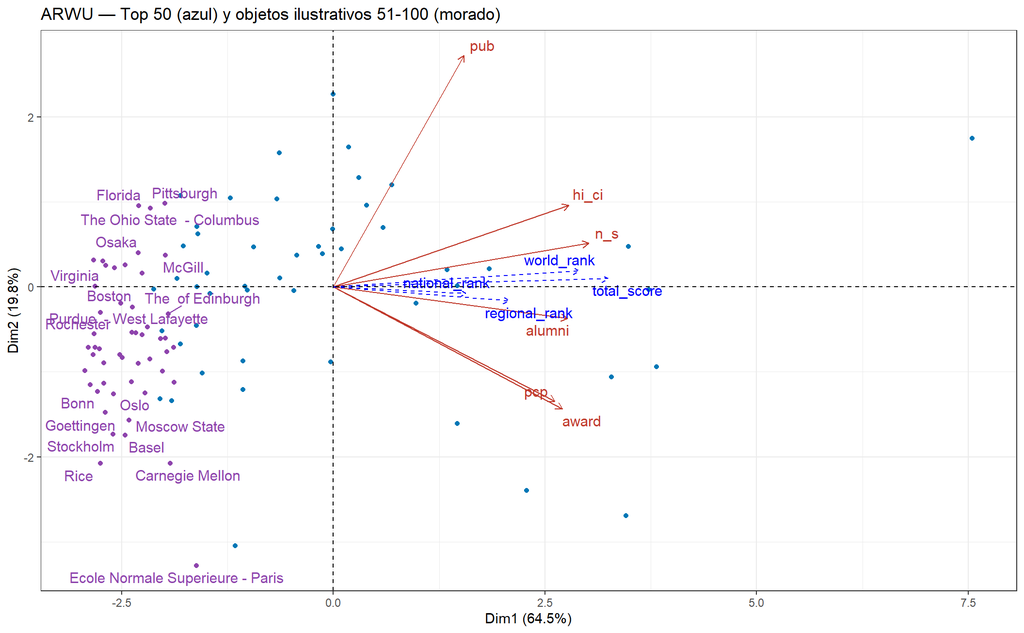

# Ejemplo: Análisis de imágenes

## ¿Qué es un píxel?

Un **píxel** (*picture element*) es la unidad mínima de una imagen digital: el punto de color más pequeño que puede representarse en pantalla o en un archivo.

- En imágenes de **escala de grises**, cada píxel tiene un único valor de intensidad en $[0, 1]$ (0 = negro, 1 = blanco).
- En imágenes **a color**, cada píxel contiene **tres valores** de intensidad, uno por canal: **Rojo (R)**, **Verde (G)** y **Azul (B)**.
- Una imagen de resolución $n \times m$ tiene $n$ filas y $m$ columnas de píxeles — en total $n \cdot m$ píxeles.

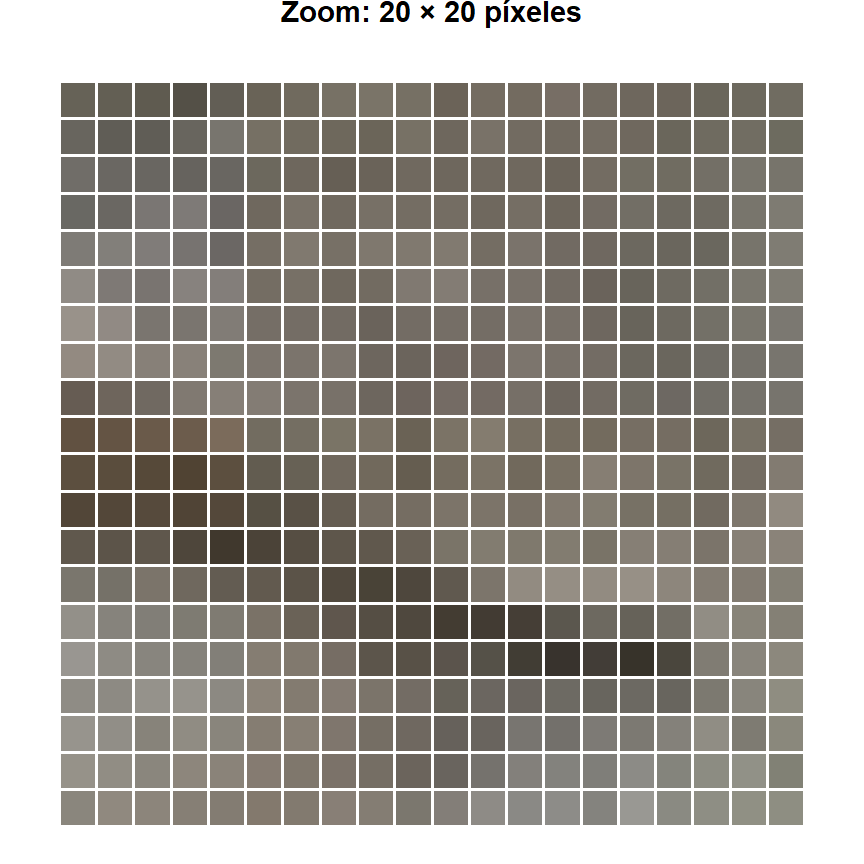

**Note**

Los valores se almacenan usualmente como enteros en $[0, 255]$ (8 bits por canal). `readJPEG()` los normaliza automáticamente al intervalo $[0, 1]$.

## El tensor RGB

Una imagen a color de $n \times m$ píxeles se representa como un **tensor** (arreglo tridimensional):

$$\mathbf{T} \in \mathbb{R}^{n \times m \times 3}$$

- **Dimensión 1** — $n$ filas (alto de la imagen)
- **Dimensión 2** — $m$ columnas (ancho de la imagen)
- **Dimensión 3** — 3 canales de color: R, G, B

Cada **canal** es una “rebanada” o subtabla del tensor: una matriz $n \times m$ cuyos valores indican la intensidad de ese color primario en cada píxel.

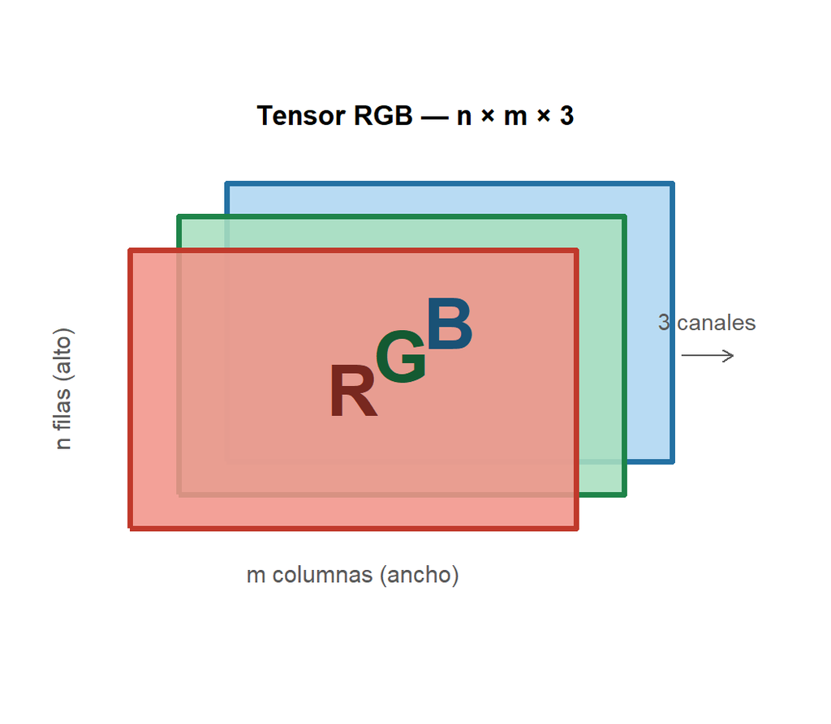

## ACP aplicado a datos visuales

Una imagen digital en color es un **arreglo tridimensional** de dimensiones $n \times m \times 3$:

- $n$: número de filas de píxeles (altura)
- $m$: número de columnas de píxeles (ancho)
- $3$: canales de color R, G, B

## ACP aplicado a datos visuales

Cada canal es una **matriz de intensidades** en $[0,1]$. Si aplicamos ACP a cada canal por separado:

$$\text{Canal}_k = U_k\, L_k\, V_k^\prime, \quad k \in \{R, G, B\}$$

La reconstrucción usando solo las primeras $q$ componentes es:

$$\widehat{\text{Canal}}_k^{(q)} = U_k^{(q)}\, L_k^{(q)}\, \left(V_k^{(q)}\right)^\prime$$

donde $U_k^{(q)}$ y $V_k^{(q)}$ son las primeras $q$ columnas de $U_k$ y $V_k$.

## Monte Rushmore

```r
library(pacman)
p_load(jpeg, tidyverse)

url_img <- "https://raw.githubusercontent.com/jgbabativam/Curso_Multivariado/main/images/rushmore.jpg"

tmp <- tempfile(fileext = ".jpg")
download.file(url_img, tmp, mode = "wb")

imagen <- readJPEG(tmp)

cat("Dimensiones:", paste(dim(imagen), collapse = " × "), "\n")
```

```
Dimensiones: 853 × 1280 × 3
```

```r
cat("Filas (alto):", nrow(imagen), "| Columnas (ancho):", ncol(imagen), "| Canales RGB:", dim(imagen)[3])
```

```
Filas (alto): 853 | Columnas (ancho): 1280 | Canales RGB: 3
```

[figure not shown]

## PCA aplicado a cada canal RGB

```r
img <- imagen[seq(1, nrow(imagen), 3),
              seq(1, ncol(imagen), 3), ]

# ACP por canal (sin centrado: preserva la escala de intensidades)
pca_r <- prcomp(img[,,1], center = FALSE)
pca_g <- prcomp(img[,,2], center = FALSE)
pca_b <- prcomp(img[,,3], center = FALSE)

# Creo la lista con los PCA del RGB.
pca_imagen <- list(pca_r, pca_g, pca_b)

# Matriz Reconstruida
reconstruir <- function(pca_ls, n_comp) {
  sapply(pca_ls, function(p) {
    rec <- p$x[, 1:n_comp] %*% t(p$rotation[, 1:n_comp])
    pmax(0, pmin(1, rec))
  }, simplify = "array")
}

## Generar Imágenes
getwd()
for (i in seq.int(3, round(nrow(imagen) - 700), length.out = 10)) {
  pca.img <- sapply(pca_imagen, function(j) {
    compressed.img <- j$x[,1:i] %*% t(j$rotation[,1:i])
  }, simplify = 'array')
  writeJPEG(pca.img, paste('imagen_con_', round(i,0), '_componentes.jpg', sep = ''))
}
```

**Note**

Se usa `prcomp(..., center = FALSE)` porque los valores de intensidad ya están en $[0,1]$ y centrar alteraría la escala de grises. La reconstrucción es $\hat{X} = U^{(q)} \cdot (V^{(q)})^\prime$.

## Varianza explicada acumulada — los tres canales

```r
# Varianza acumulada para cada canal RGB
var_r <- cumsum(pca_r$sdev^2) / sum(pca_r$sdev^2)
var_g <- cumsum(pca_g$sdev^2) / sum(pca_g$sdev^2)
var_b <- cumsum(pca_b$sdev^2) / sum(pca_b$sdev^2)

max_comp <- min(150, length(var_r))

df_rgb <- bind_rows(
  data.frame(comp = seq_len(max_comp), var_acum = var_r[seq_len(max_comp)] * 100, Canal = "R"),
  data.frame(comp = seq_len(max_comp), var_acum = var_g[seq_len(max_comp)] * 100, Canal = "G"),
  data.frame(comp = seq_len(max_comp), var_acum = var_b[seq_len(max_comp)] * 100, Canal = "B")
)

puntos_ref <- df_rgb |> filter(comp %in% c(3, 10, 30, 100))

ggplot(df_rgb, aes(x = comp, y = var_acum, color = Canal)) +
  geom_line(linewidth = 1.1) +
  geom_point(data = puntos_ref, size = 3) +
  geom_text(data = puntos_ref |> filter(Canal == "R"),
            aes(label = paste0(comp, " comp.\n", round(var_acum, 1), "%")),
            vjust = -0.6, size = 3.0, color = "#C0392B") +
  scale_color_manual(values = c("R" = "#C0392B", "G" = "#1E8449", "B" = "#2471A3")) +
  scale_x_continuous(limits = c(1, 150)) +
  labs(title = "Varianza acumulada — canales R, G y B",
       x = "Número de componentes principales",
       y = "Varianza explicada acumulada (%)",
       color = "Canal") +
  theme_bw()
```

[output not shown]